# ggplot2 그래프

# 상자 그림(Box Plot)

상자그림은 데이터가 퍼져있는 형태 즉, 분포를 직사각형 모양으로 표현한 그래프이다. 평균만 볼 때보다 데이터의 특징을 더 잘 이해할 수 있다.

## 구동방식별 고속도로연비의 데이터분포 확인

상자그림을 통해, mpg 데이터의 고속도로연비(hwy) 변수값이 어떤 분포를 가지고 있는지 구동방식(drv)별로 살펴보자.

앞서 데이터를 전체적으로 살펴볼 때 **boxplot()**이용하여 이상값 여부와 데이터의 분포를 살펴보았다. 고속도로연비 변수 하나에 대한 상자그림은 아래와 같다.

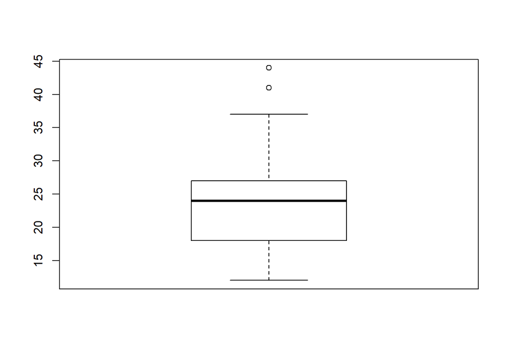

```r
boxplot(mpg$hwy)
```

그룹별로 상자그림을 그리려면 **~** 을 사용하여 그룹 변수를 지정한다.

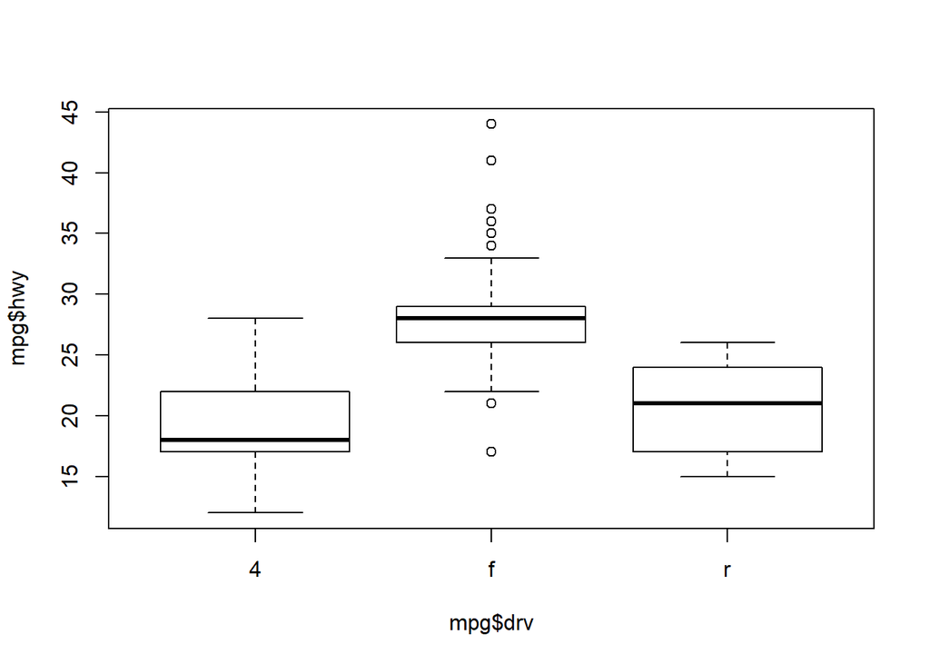

```r
boxplot(mpg$hwy ~ mpg$drv)
```

ggplot2패키지를 사용하여 상자그림을 그리려면, ggplote()에 **geom_boxplot()**을 추가한다. y축에 상자그림의 대상 변수를 지정해야 한다.

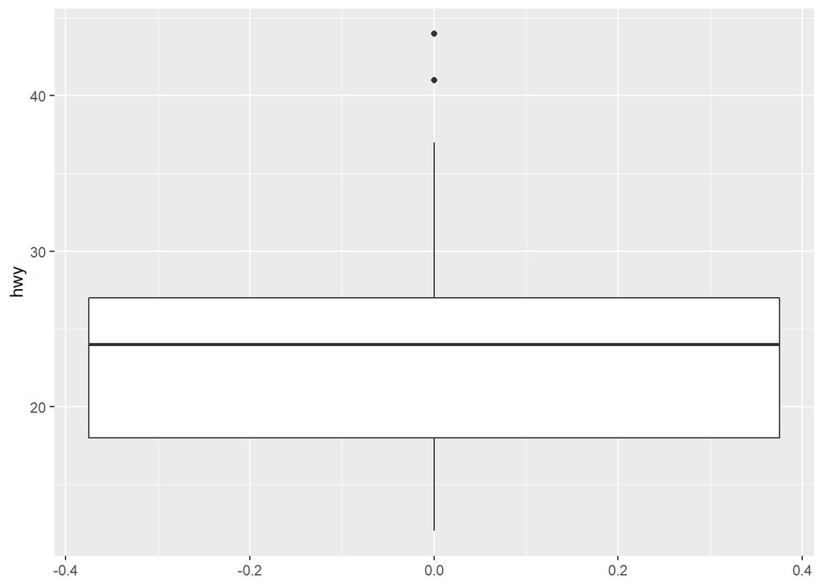

```r
ggplot(mpg, aes(y=hwy)) + geom_boxplot()
```

그룹별로 상자그림을 그리기 위해 x축에 그룹 변수를 지정한다.

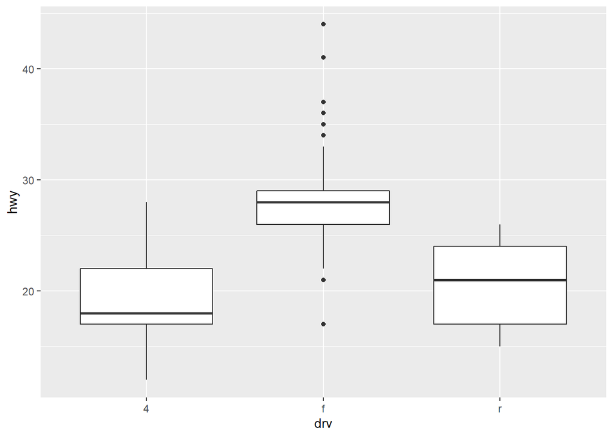

```r
ggplot(mpg, aes(x=drv, y=hwy)) + geom_boxplot()
```

위의 상자그림에서 색을 지정하면 다음과 같다.

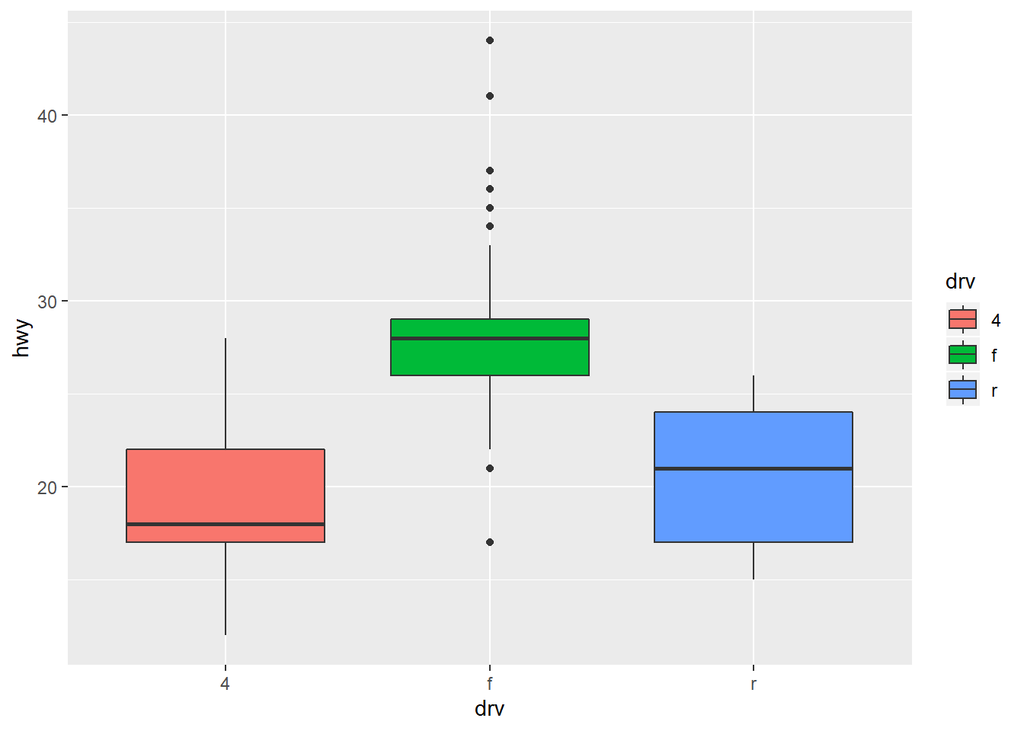

```r
ggplot(mpg, aes(x=drv, y=hwy, fill=drv)) + geom_boxplot()
```

자동차 종류(class)별로 도시연비(cty)의 차이를 상자그림으로 비교해 보면 다음과 같다. 위의 R코드와 동일한 기능을 한다.

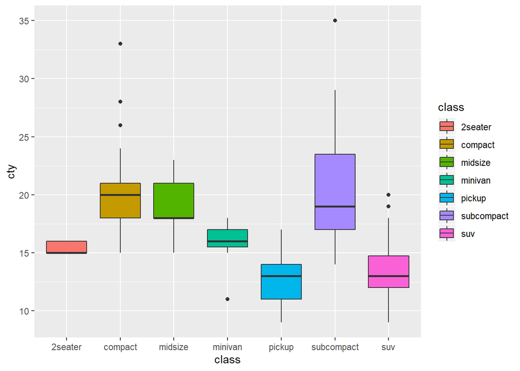

```r
ggplot(mpg, aes(x=class, y=cty)) + geom_boxplot(aes(fill=class))
```